# 사이킷런

https://scikit-learn.org/stable/tutorial/machine_learning_map/

# AND, OR, XOR, NOT 학습하기

### AND 연산

- 0 : 거짓, 1 : 참
- 서로 다른 두개의 값이 모두 참(1)일때 결과는 참이된다.

| X(값1) | Y(값2) | Z(결과) |
| --- | --- | --- |
| 0 | 0 | 0 |
| 1 | 0 | 0 |
| 0 | 1 | 0 |
| 1 | 1 | 1 |

### 사이킷런 모듈 설치

!pip install sklearn

### 지도학습 : 정답을 알려준다

1. 학습용 데이터 -----> train_data (X_data)
2. 학습용 정답 ----------> train_label(X_label)
3. 테스트용 데이터 ------> test_data (y_data)
4. 테스트용 정답 --------> test_label (y_label)

```python
# 사이킷런 모듈 호출
from sklearn import svm

'''
데이터전처리 --> train_data,train_label,test_data,test_label
'''

# 컴퓨터 학습시킬 알고리즘 선택
clf = svm.SVC()

# 컴퓨터 학습
#clf.fit(학습용데이터, 학습용정답)
clf.fit(train_data, train_label)

# 결과예측
clf.predict(test_data)

# 컴퓨터는 예측에 대한 결과를 출력한다.
```

- AND 연산 모델링

```python
# 사이킷런 모듈 호출
from sklearn import svm

# 컴퓨터 학습시킬 알고리즘 선택
clf = svm.SVC()

# 컴퓨터 학습
#clf.fit(학습용데이터, 학습용정답)
clf.fit([
        [0, 0],
        [0, 1],
        [1, 0],
        [1, 1]
], [0, 0, 0, 1])


# 결과예측
predict = clf.predict([[0, 1], [1, 1]])

print("AND에 대한 연산결과는: ", predict)
```

```
AND에 대한 연산결과는:  [0 1]
```

```python
# 정확도 출력
from sklearn import svm, metrics

test_lable = [0,1]

#score = metrics.accuracy_score(예측질문, 예측질문에대한정답)
score = metrics.accuracy_score(predict, test_lable)

print("AND 연산결과 정확도: ", score)
```

```
AND 연산결과 정확도:  1.0
```

### OR 연산

- 0 : 거짓, 1 : 참
- 서로 다른 두개의 값중에서 1개가 참(1)일때 결과는 참이된다.

| X(값1) | Y(값2) | Z(결과) |
| --- | --- | --- |
| 0 | 0 | 0 |
| 1 | 0 | 1 |
| 0 | 1 | 1 |
| 1 | 1 | 1 |

### XOR 연산

- 0 : 거짓, 1 : 참
- 서로 다른 두개의 값이 모두 다를때 결과는 참이된다.

| X(값1) | Y(값2) | Z(결과) |
| --- | --- | --- |
| 0 | 0 | 0 |
| 1 | 0 | 1 |
| 0 | 1 | 1 |
| 1 | 1 | 0 |

### NOT 연산 (AND/OR/XOR)

- 0 : 거짓, 1 : 참
- 출력된 결과를 반대로 출력한다.( 0 -> 1, 1 -> 0 )

| X(값1) | Y(값2) | Z(결과) | ZZ(NOT) |
| --- | --- | --- | --- |
| 0 | 0 | 0 | 1 |
| 1 | 0 | 0 | 1 |
| 0 | 1 | 0 | 1 |
| 1 | 1 | 1 | 0 |

# 데이터 저장소 https://archive.ics.uci.edu

# 실습 : 붓꽃 품종 분류하기

sepal_length sepal_width petal_length petal_width name

5.1 3.5 1.4 0.2 Iris-setosa

```
7               3.2        4.7             1.4           Iris-versicolor
```

4.9 2.5 4.5 1.7 Iris-virginica

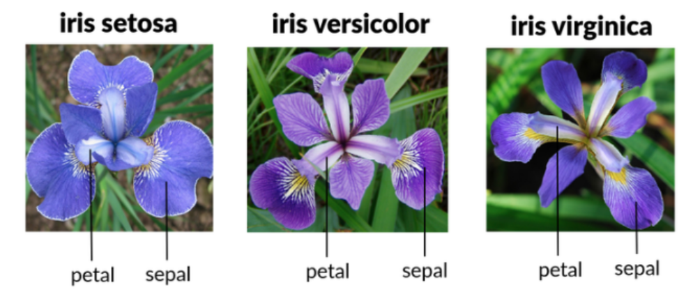

```python
import pandas as pd
from sklearn import svm, metrics

csv = pd.read_csv('iris.csv')
data = csv[['sepal_length','sepal_width','petal_length','petal_width']]
label = csv['name']


# 컴퓨터 학습시킬 알고리즘 선택
clf = svm.SVC()

# 컴퓨터 학습
clf.fit(data, label)


# 결과예측
predict = clf.predict([[8.3, 1.7, 3.4, 2.2]])

print("예측결과는: ", predict)


# 정확도 출력
#score = metrics.accuracy_score(predict, test_lable)
#print("AND 연산결과 정확도: ", score)
```

```
예측결과는:  ['Iris-versicolor']
```

```python
import pandas as pd
from sklearn import svm, metrics
import random, re


# 데이터 불러오기
csv = []

with open('iris.csv', 'r', encoding='utf-8') as fp :
    # 데이터를 한줄씩 읽어오기
    for line in fp :
        line = line.strip()     # 좌우 공백 제거
        cols = line.split(',')  # 필드(열)를 콤마기호로 구분

        # 문자열 데이터를 숫자로 변환
        fn = lambda n: float(n) if re.match(r'^[0-9\.]+$', n) else n
        cols = list(map(fn, cols))
        csv.append(cols)

# 헤더를 제거한다.
del csv[0]


# 데이터 섞어주기(셔플)
random.shuffle(csv)


# ------------------------------------------------------------------------------

# 학습전용 & 테스트전용으로 데이터를 2 : 1 비율로 조정 (전체 150개)
# 학습용 = 100개, 테스트용 = 50개

total_len = len(csv)   # 전체 갯수
print(total_len)

train_len = int(total_len * 2/3)
print(train_len)

train_data = []
train_label = []
test_data = []
test_label = []

for i in range(total_len) :
    data = csv[i][0:4]
    label = csv[i][4]     # 정답이 있는 name 항목의 값을 저장

    # 데이터 구분(2/3)
    if i < train_len :
        train_data.append(data)    # 100개의 데이터 입력
        train_label.append(label)
    else:
        test_data.append(data)    # 50개의 데이터 입력
        test_label.append(label)

# -----------------------------------------------------------------------------

print(len(train_data))
print(len(train_label))
print(len(test_data))
print(len(test_label))
```

```
150
100
100
100
50
50
```

```python
# 컴퓨터 학습시킬 알고리즘 선택
clf = svm.SVC()

# 컴퓨터 학습
clf.fit(train_data, train_label)


# 결과예측
predict = clf.predict(test_data)
#print("예측결과는: ", predict)


# 정확도 출력
score = metrics.accuracy_score(predict, test_label)
print("연산결과 정확도: ", score)
```

```
연산결과 정확도:  1.0
```

```python
import pandas as pd
from sklearn import svm, metrics
import random, re


# 데이터 불러오기
csv = []

with open('iris.csv', 'r', encoding='utf-8') as fp :
    # 데이터를 한줄씩 읽어오기
    for line in fp :
        line = line.strip()     # 좌우 공백 제거
        cols = line.split(',')  # 필드(열)를 콤마기호로 구분

        # 문자열 데이터를 숫자로 변환
        fn = lambda n: float(n) if re.match(r'^[0-9\.]+$', n) else n
        cols = list(map(fn, cols))
        csv.append(cols)

# 헤더를 제거한다.
del csv[0]


# 데이터 섞어주기(셔플)
random.shuffle(csv)


# ------------------------------------------------------------------------------

# 학습전용 & 테스트전용으로 데이터를 2 : 1 비율로 조정 (전체 150개)
# 학습용 = 100개, 테스트용 = 50개

total_len = len(csv)   # 전체 갯수
print(total_len)

train_len = int(total_len * 4/5)
print(train_len)

train_data = []
train_label = []
test_data = []
test_label = []

for i in range(total_len) :
    data = csv[i][0:4]
    label = csv[i][4]     # 정답이 있는 name 항목의 값을 저장

    # 데이터 구분(2/3)
    if i < train_len :
        train_data.append(data)    # 100개의 데이터 입력
        train_label.append(label)
    else:
        test_data.append(data)    # 50개의 데이터 입력
        test_label.append(label)

# -----------------------------------------------------------------------------

print(len(train_data))
print(len(train_label))
print(len(test_data))
print(len(test_label))

# 컴퓨터 학습시킬 알고리즘 선택
clf = svm.SVC()

# 컴퓨터 학습
clf.fit(train_data, train_label)


# 결과예측
predict = clf.predict(test_data)
#print("예측결과는: ", predict)


# 정확도 출력
score = metrics.accuracy_score(predict, test_label)
print("연산결과 정확도: ", score)
```

```
150
120
120
120
30
30
연산결과 정확도:  0.9
```

- 결과에 대한 보고서를 출력한다

```python
import pandas as pd
from sklearn import svm, metrics, model_selection
import random, re


# 데이터 불러오기
csv = []

with open('iris.csv', 'r', encoding='utf-8') as fp :
    # 데이터를 한줄씩 읽어오기
    for line in fp :
        line = line.strip()     # 좌우 공백 제거
        cols = line.split(',')  # 필드(열)를 콤마기호로 구분

        # 문자열 데이터를 숫자로 변환
        fn = lambda n: float(n) if re.match(r'^[0-9\.]+$', n) else n
        cols = list(map(fn, cols))
        csv.append(cols)

# 헤더를 제거한다.
del csv[0]


# 데이터 섞어주기(셔플)
random.shuffle(csv)


# ------------------------------------------------------------------------------

# 학습전용 & 테스트전용으로 데이터를 2 : 1 비율로 조정 (전체 150개)
# 학습용 = 100개, 테스트용 = 50개

total_len = len(csv)   # 전체 갯수
#print(total_len)

train_len = int(total_len * 4/5)
#print(train_len)

train_data = []
train_label = []
test_data = []
test_label = []

for i in range(total_len) :
    data = csv[i][0:4]
    label = csv[i][4]     # 정답이 있는 name 항목의 값을 저장

    # 데이터 구분(2/3)
    if i < train_len :
        train_data.append(data)    # 100개의 데이터 입력
        train_label.append(label)
    else:
        test_data.append(data)    # 50개의 데이터 입력
        test_label.append(label)

# -----------------------------------------------------------------------------

#print(len(train_data))
#print(len(train_label))
#print(len(test_data))
#print(len(test_label))

# 컴퓨터 학습시킬 알고리즘 선택
clf = svm.SVC()

# 컴퓨터 학습
clf.fit(train_data, train_label)


# 결과예측
predict = clf.predict(test_data)
#print("예측결과는: ", predict)


# 정확도 출력
score = metrics.accuracy_score(predict, test_label)
print("연산결과 정확도: ", score)
print()
# 보고서 출력
report = metrics.classification_report(predict, test_label)
print(report)
```

```
연산결과 정확도:  0.9666666666666667

                 precision    recall  f1-score   support

    Iris-setosa       1.00      1.00      1.00         9
Iris-versicolor       0.92      1.00      0.96        12
 Iris-virginica       1.00      0.89      0.94         9

       accuracy                           0.97        30
      macro avg       0.97      0.96      0.97        30
   weighted avg       0.97      0.97      0.97        30
```

# 실습 : 언어 판독

#### 1. 파일을 읽어들인다.

```python
                  # 분석  정확도    보고서
from sklearn import svm, metrics, model_selection
import os.path, re, json
from glob import glob

files = glob('./lang/train/*.txt')

print(files)
```

[output not shown]

```python
                  # 분석  정확도    보고서
from sklearn import svm, metrics, model_selection
import os.path, re, json
from glob import glob

files = glob('./lang/train/*.txt')

for file_name in files :
    basename = os.path.basename(file_name)
    print(basename)
```

```
en-1.txt
en-2.txt
en-3.txt
en-4.txt
en-5.txt
fr-10.txt
fr-6.txt
fr-7.txt
fr-8.txt
fr-9.txt
id-11.txt
id-12.txt
id-13.txt
id-14.txt
id-15.txt
tl-16.txt
tl-17.txt
tl-18.txt
tl-19.txt
tl-20.txt
```

- 정답 레이블을 함께 출력한다

```python
                  # 분석  정확도    보고서
from sklearn import svm, metrics, model_selection
import os.path, re, json
from glob import glob

files = glob('./lang/train/*.txt')

for file_name in files :
    basename = os.path.basename(file_name)
    lang = basename.split('-')[0]
    print(basename, lang)
```

```
en-1.txt en
en-2.txt en
en-3.txt en
en-4.txt en
en-5.txt en
fr-10.txt fr
fr-6.txt fr
fr-7.txt fr
fr-8.txt fr
fr-9.txt fr
id-11.txt id
id-12.txt id
id-13.txt id
id-14.txt id
id-15.txt id
tl-16.txt tl
tl-17.txt tl
tl-18.txt tl
tl-19.txt tl
tl-20.txt tl
```

- 텍스트 내용을 읽어온다.

```python
                  # 분석  정확도    보고서
from sklearn import svm, metrics, model_selection
import os.path, re, json
from glob import glob

files = glob('./lang/train/*.txt')

train_data = []
train_label = []

for file_name in files :
    basename = os.path.basename(file_name)
    lang = basename.split('-')[0]

    # 텍스트 추출하기
    file = open(file_name, 'r', encoding='utf-8')
    text = file.read()
    text = text.lower()   # 소문자로 변환
    file.close()


    # 알파벳 출현빈도를 위한 초기값 설정
    code_a = ord('a')   # 97
    code_z = ord('z')   # 122

    # 알파벳 26자를 저장할 초기 변수 선언
    count = [0,0,0,0,0,0,0,0,0,0,0,0,0,0,0,0,0,0,0,0,0,0,0,0,0,0]

                # 97              98
    #index_a = (code_a - 가져온글자를ord('알파벳')) * -1


    # 알파벳 출현빈도 구하기
    for character in text :
        code_current = ord(character)

        if code_a <= code_current <= code_z :    # 알파벳 소문자만 해당된다
            count[code_current - code_a] += 1

    #print(lang, count)


    # 정규화 작업 ( Normalization)
    # 데이터의 값이 크면 분포도가 넓어지기 때문에 표준화시켜주어야 한다.
    # 데이터의 값을 0.0 ~ 1.0 사이의 값으로 변환시킨다.

    total = sum(count)  # 전체 합계를 구한다.
    count = list(map(lambda n: n/total, count))  # 각각의 값을 total로 나눈다

    train_data.append(count)  # 학습용 데이터를 저장한다.
    train_label.append(lang)  # 학습용 정답을 저장한다

# ------------------------------------------------------------------------------

files = glob('./lang/test/*.txt')

test_data = []
test_label = []

for file_name in files :
    basename = os.path.basename(file_name)
    lang = basename.split('-')[0]

    # 텍스트 추출하기
    file = open(file_name, 'r', encoding='utf-8')
    text = file.read()
    text = text.lower()   # 소문자로 변환
    file.close()


    # 알파벳 출현빈도를 위한 초기값 설정
    code_a = ord('a')   # 97
    code_z = ord('z')   # 122

    # 알파벳 26자를 저장할 초기 변수 선언
    count = [0,0,0,0,0,0,0,0,0,0,0,0,0,0,0,0,0,0,0,0,0,0,0,0,0,0]

                # 97              98
    #index_a = (code_a - 가져온글자를ord('알파벳')) * -1


    # 알파벳 출현빈도 구하기
    for character in text :
        code_current = ord(character)

        if code_a <= code_current <= code_z :    # 알파벳 소문자만 해당된다
            count[code_current - code_a] += 1

    #print(lang, count)


    # 정규화 작업 ( Normalization)
    # 데이터의 값이 크면 분포도가 넓어지기 때문에 표준화시켜주어야 한다.
    # 데이터의 값을 0.0 ~ 1.0 사이의 값으로 변환시킨다.

    total = sum(count)  # 전체 합계를 구한다.
    count = list(map(lambda n: n/total, count))  # 각각의 값을 total로 나눈다

    test_data.append(count)  # 학습용 데이터를 저장한다.
    test_label.append(lang)  # 학습용 정답을 저장한다

# ------------------------------------------------------------------------------

clf = svm.SVC()

clf.fit(train_data, train_label)

predict = clf.predict(test_data)
print(predict)

score = metrics.accuracy_score(predict, test_label)
report = metrics.classification_report(predict, test_label)

print("정확도: ", score)
print()
print()
print(report)
```

[output not shown]

네이버나 구글에서 팝송가사 2곡씩 공유폴더 --> lang/test/6.txt

```python
영어, 프랑스어, 인도네이시어, 타갈리아어, 독일어, 스페인어
```

```python
                  # 분석  정확도    보고서
from sklearn import svm, metrics, model_selection
import os.path, re, json
from glob import glob

files = glob('./lang/train/*.txt')

train_data = []
train_label = []

for file_name in files :
    basename = os.path.basename(file_name)
    lang = basename.split('-')[0]

    # 텍스트 추출하기
    file = open(file_name, 'r', encoding='utf-8')
    text = file.read()
    text = text.lower()   # 소문자로 변환
    file.close()


    # 알파벳 출현빈도를 위한 초기값 설정
    code_a = ord('a')   # 97
    code_z = ord('z')   # 122

    # 알파벳 26자를 저장할 초기 변수 선언
    count = [0,0,0,0,0,0,0,0,0,0,0,0,0,0,0,0,0,0,0,0,0,0,0,0,0,0]

                # 97              98
    #index_a = (code_a - 가져온글자를ord('알파벳')) * -1


    # 알파벳 출현빈도 구하기
    for character in text :
        code_current = ord(character)

        if code_a <= code_current <= code_z :    # 알파벳 소문자만 해당된다
            count[code_current - code_a] += 1

    #print(lang, count)


    # 정규화 작업 ( Normalization)
    # 데이터의 값이 크면 분포도가 넓어지기 때문에 표준화시켜주어야 한다.
    # 데이터의 값을 0.0 ~ 1.0 사이의 값으로 변환시킨다.

    total = sum(count)  # 전체 합계를 구한다.
    count = list(map(lambda n: n/total, count))  # 각각의 값을 total로 나눈다

    train_data.append(count)  # 학습용 데이터를 저장한다.
    train_label.append(lang)  # 학습용 정답을 저장한다

# ------------------------------------------------------------------------------

files = glob('./lang/test/*.txt')

test_data = []
test_label = []

for file_name in files :
    basename = os.path.basename(file_name)
    lang = basename.split('-')[0]

    # 텍스트 추출하기
    file = open(file_name, 'r', encoding='utf-8')
    text = file.read()
    text = text.lower()   # 소문자로 변환
    file.close()


    # 알파벳 출현빈도를 위한 초기값 설정
    code_a = ord('a')   # 97
    code_z = ord('z')   # 122

    # 알파벳 26자를 저장할 초기 변수 선언
    count = [0,0,0,0,0,0,0,0,0,0,0,0,0,0,0,0,0,0,0,0,0,0,0,0,0,0]

                # 97              98
    #index_a = (code_a - 가져온글자를ord('알파벳')) * -1


    # 알파벳 출현빈도 구하기
    for character in text :
        code_current = ord(character)

        if code_a <= code_current <= code_z :    # 알파벳 소문자만 해당된다
            count[code_current - code_a] += 1

    #print(lang, count)


    # 정규화 작업 ( Normalization)
    # 데이터의 값이 크면 분포도가 넓어지기 때문에 표준화시켜주어야 한다.
    # 데이터의 값을 0.0 ~ 1.0 사이의 값으로 변환시킨다.

    total = sum(count)  # 전체 합계를 구한다.
    count = list(map(lambda n: n/total, count))  # 각각의 값을 total로 나눈다

    test_data.append(count)  # 학습용 데이터를 저장한다.
    test_label.append(lang)  # 학습용 정답을 저장한다

# ------------------------------------------------------------------------------

clf = svm.SVC()

clf.fit(train_data, train_label)

predict = clf.predict(test_data)
print(predict)

score = metrics.accuracy_score(predict, test_label)
report = metrics.classification_report(predict, test_label)

print("정확도: ", score)
print()
print()
print(report)
```

```
['en' 'en' 'en' 'en' 'fr' 'fr' 'fr' 'fr' 'id' 'id' 'tl' 'id' 'fr' 'fr'
 'tl' 'tl']
정확도:  0.8125


              precision    recall  f1-score   support

          en       1.00      1.00      1.00         4
          fr       1.00      0.67      0.80         6
          id       0.75      1.00      0.86         3
          sp       0.00      0.00      0.00         0
          tl       1.00      0.67      0.80         3

    accuracy                           0.81        16
   macro avg       0.75      0.67      0.69        16
weighted avg       0.95      0.81      0.86        16
```

#### precision : 정밀도 -> 예측한 비율

#### recall : 재현율 -> 예측값 중에서 실제로 예측한 비율

#### f1-score : 정밀도 + 재현율의 평균조화(실제 성능비교)

#### accuracy : 정확도 -> 예측이 정답과 얼마나 일치하는가?

# 실습: 데이터 시각화

```python
                  # 분석  정확도    보고서
from sklearn import svm, metrics, model_selection
import os.path, re, json
from glob import glob

files = glob('./lang/train/*.txt')

train_data = []
train_label = []

for file_name in files :
    basename = os.path.basename(file_name)
    lang = basename.split('-')[0]

    # 텍스트 추출하기
    file = open(file_name, 'r', encoding='utf-8')
    text = file.read()
    text = text.lower()   # 소문자로 변환
    file.close()


    # 알파벳 출현빈도를 위한 초기값 설정
    code_a = ord('a')   # 97
    code_z = ord('z')   # 122

    # 알파벳 26자를 저장할 초기 변수 선언
    count = [0,0,0,0,0,0,0,0,0,0,0,0,0,0,0,0,0,0,0,0,0,0,0,0,0,0]

                # 97              98
    #index_a = (code_a - 가져온글자를ord('알파벳')) * -1


    # 알파벳 출현빈도 구하기
    for character in text :
        code_current = ord(character)

        if code_a <= code_current <= code_z :    # 알파벳 소문자만 해당된다
            count[code_current - code_a] += 1

    #print(lang, count)


    # 정규화 작업 ( Normalization)
    # 데이터의 값이 크면 분포도가 넓어지기 때문에 표준화시켜주어야 한다.
    # 데이터의 값을 0.0 ~ 1.0 사이의 값으로 변환시킨다.

    total = sum(count)  # 전체 합계를 구한다.
    count = list(map(lambda n: n/total, count))  # 각각의 값을 total로 나눈다

    train_data.append(count)  # 학습용 데이터를 저장한다.
    train_label.append(lang)  # 학습용 정답을 저장한다

# ------------------------------------------------------------------------------

files = glob('./lang/test/*.txt')

test_data = []
test_label = []

for file_name in files :
    basename = os.path.basename(file_name)
    lang = basename.split('-')[0]

    # 텍스트 추출하기
    file = open(file_name, 'r', encoding='utf-8')
    text = file.read()
    text = text.lower()   # 소문자로 변환
    file.close()


    # 알파벳 출현빈도를 위한 초기값 설정
    code_a = ord('a')   # 97
    code_z = ord('z')   # 122

    # 알파벳 26자를 저장할 초기 변수 선언
    count = [0,0,0,0,0,0,0,0,0,0,0,0,0,0,0,0,0,0,0,0,0,0,0,0,0,0]

                # 97              98
    #index_a = (code_a - 가져온글자를ord('알파벳')) * -1


    # 알파벳 출현빈도 구하기
    for character in text :
        code_current = ord(character)

        if code_a <= code_current <= code_z :    # 알파벳 소문자만 해당된다
            count[code_current - code_a] += 1

    #print(lang, count)


    # 정규화 작업 ( Normalization)
    # 데이터의 값이 크면 분포도가 넓어지기 때문에 표준화시켜주어야 한다.
    # 데이터의 값을 0.0 ~ 1.0 사이의 값으로 변환시킨다.

    total = sum(count)  # 전체 합계를 구한다.
    count = list(map(lambda n: n/total, count))  # 각각의 값을 total로 나눈다

    test_data.append(count)  # 학습용 데이터를 저장한다.
    test_label.append(lang)  # 학습용 정답을 저장한다

# ------------------------------------------------------------------------------

# 시각화
graph_dict = {}

for i in range(0, len(train_label)) :
    label = train_label[i]
    data = train_data[i]

    if not (label in graph_dict) :
        graph_dict[label] = data

asclist = [[chr(n) for n in range(97, 97+26)]]
print(asclist)
```

```
[['a', 'b', 'c', 'd', 'e', 'f', 'g', 'h', 'i', 'j', 'k', 'l', 'm', 'n', 'o', 'p', 'q', 'r', 's', 't', 'u', 'v', 'w', 'x', 'y', 'z']]
```

```
[['a', 'b', 'c', 'd', 'e', 'f', 'g', 'h', 'i', 'j', 'k', 'l', 'm', 'n', 'o', 'p', 'q', 'r', 's', 't', 'u', 'v', 'w', 'x', 'y', 'z']]
```

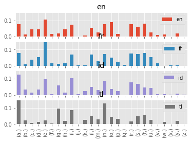

```python
                  # 분석  정확도    보고서
from sklearn import svm, metrics, model_selection
import os.path, re, json
from glob import glob
import matplotlib.pyplot as plt

files = glob('./lang/train/*.txt')

train_data = []
train_label = []

for file_name in files :
    basename = os.path.basename(file_name)
    lang = basename.split('-')[0]

    # 텍스트 추출하기
    file = open(file_name, 'r', encoding='utf-8')
    text = file.read()
    text = text.lower()   # 소문자로 변환
    file.close()


    # 알파벳 출현빈도를 위한 초기값 설정
    code_a = ord('a')   # 97
    code_z = ord('z')   # 122

    # 알파벳 26자를 저장할 초기 변수 선언
    count = [0,0,0,0,0,0,0,0,0,0,0,0,0,0,0,0,0,0,0,0,0,0,0,0,0,0]

                # 97              98
    #index_a = (code_a - 가져온글자를ord('알파벳')) * -1


    # 알파벳 출현빈도 구하기
    for character in text :
        code_current = ord(character)

        if code_a <= code_current <= code_z :    # 알파벳 소문자만 해당된다
            count[code_current - code_a] += 1

    #print(lang, count)


    # 정규화 작업 ( Normalization)
    # 데이터의 값이 크면 분포도가 넓어지기 때문에 표준화시켜주어야 한다.
    # 데이터의 값을 0.0 ~ 1.0 사이의 값으로 변환시킨다.

    total = sum(count)  # 전체 합계를 구한다.
    count = list(map(lambda n: n/total, count))  # 각각의 값을 total로 나눈다

    train_data.append(count)  # 학습용 데이터를 저장한다.
    train_label.append(lang)  # 학습용 정답을 저장한다

# ------------------------------------------------------------------------------

files = glob('./lang/test/*.txt')

test_data = []
test_label = []

for file_name in files :
    basename = os.path.basename(file_name)
    lang = basename.split('-')[0]

    # 텍스트 추출하기
    file = open(file_name, 'r', encoding='utf-8')
    text = file.read()
    text = text.lower()   # 소문자로 변환
    file.close()


    # 알파벳 출현빈도를 위한 초기값 설정
    code_a = ord('a')   # 97
    code_z = ord('z')   # 122

    # 알파벳 26자를 저장할 초기 변수 선언
    count = [0,0,0,0,0,0,0,0,0,0,0,0,0,0,0,0,0,0,0,0,0,0,0,0,0,0]

                # 97              98
    #index_a = (code_a - 가져온글자를ord('알파벳')) * -1


    # 알파벳 출현빈도 구하기
    for character in text :
        code_current = ord(character)

        if code_a <= code_current <= code_z :    # 알파벳 소문자만 해당된다
            count[code_current - code_a] += 1

    #print(lang, count)


    # 정규화 작업 ( Normalization)
    # 데이터의 값이 크면 분포도가 넓어지기 때문에 표준화시켜주어야 한다.
    # 데이터의 값을 0.0 ~ 1.0 사이의 값으로 변환시킨다.

    total = sum(count)  # 전체 합계를 구한다.
    count = list(map(lambda n: n/total, count))  # 각각의 값을 total로 나눈다

    test_data.append(count)  # 학습용 데이터를 저장한다.
    test_label.append(lang)  # 학습용 정답을 저장한다

# ------------------------------------------------------------------------------

# 시각화
graph_dict = {}

for i in range(0, len(train_label)) :
    label = train_label[i]
    data = train_data[i]

    if not (label in graph_dict) :
        graph_dict[label] = data

asclist = [[chr(n) for n in range(97, 97+26)]]
print(asclist)

df = pd.DataFrame(graph_dict, index=asclist)

plt.style.use('ggplot')
df.plot(kind='bar', subplots=True, ylim=(0, 0.15))
plt.savefig('lang_plot.png')
```

```python
clf = svm.SVC()

clf.fit(train_data, train_label)

predict = clf.predict(test_data)
print(predict)

score = metrics.accuracy_score(predict, test_label)
report = metrics.classification_report(predict, test_label)

print("정확도: ", score)
print()
print()
print(report)
```

[output not shown]

# 이미지 분석

```python
!pip install opencv-python
```

## https://opencv.org

```python
import urllib.request as req
import cv2

url = "http://uta.pw/shodou/img/28/214.png"
req.urlretrieve(url, 'test.png')

img = cv2.imread('test.png')
print(img)
```

```
[[[255 255 255]
  [255 255 255]
  [255 255 255]
  ...
  [255 255 255]
  [255 255 255]
  [255 255 255]]

 [[255 255 255]
  [255 255 255]
  [255 255 255]
  ...
  [255 255 255]
  [255 255 255]
  [255 255 255]]

 [[255 255 255]
  [255 255 255]
  [255 255 255]
  ...
  [255 255 255]
  [255 255 255]
  [255 255 255]]

 ...

 [[255 255 255]
  [255 255 255]
  [255 255 255]
  ...
  [255 255 255]
  [255 255 255]
  [255 255 255]]

 [[255 255 255]
  [255 255 255]
  [255 255 255]
  ...
  [255 255 255]
  [255 255 255]
  [255 255 255]]

 [[255 255 255]
  [255 255 255]
  [255 255 255]
  ...
  [255 255 255]
  [255 255 255]
  [255 255 255]]]
```

```python
R G B   --> B G R
```

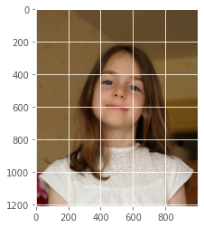

```python
import cv2
import matplotlib.pyplot as plt

img = cv2.imread('girl.jpg')
plt.imshow(cv2.cvtColor(img, cv2.COLOR_BGR2RGB))
plt.show()
```

- 격자무늬 해제

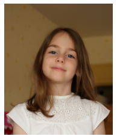

```python
import cv2
import matplotlib.pyplot as plt

img = cv2.imread('girl.jpg')
plt.imshow(cv2.cvtColor(img, cv2.COLOR_BGR2RGB))
plt.axis('off')  # 격자무늬 해제
plt.show()
```

- 이미지 저장하기

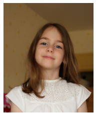

```python
import cv2
import matplotlib.pyplot as plt

img = cv2.imread('girl.jpg')

cv2.imwrite('girl2.jpg', img)

plt.imshow(cv2.cvtColor(img, cv2.COLOR_BGR2RGB))
plt.axis('off')  # 격자무늬 해제
plt.show()
```

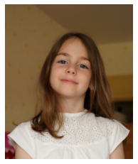

```python
import cv2
import matplotlib.pyplot as plt

img = cv2.imread('girl2.jpg')
plt.imshow(cv2.cvtColor(img, cv2.COLOR_BGR2RGB))
plt.axis('off')  # 격자무늬 해제
plt.show()
```

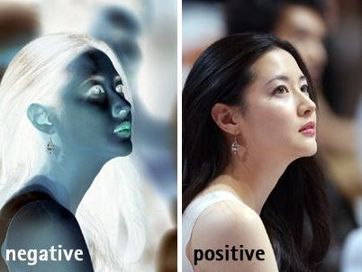

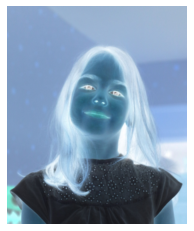

```python
import cv2
import matplotlib.pyplot as plt

img = cv2.imread('girl2.jpg')

# 네거티브 반전
img = 255 - img

plt.imshow(cv2.cvtColor(img, cv2.COLOR_BGR2RGB))
plt.axis('off')  # 격자무늬 해제
plt.show()
```

- 그레이스케일 (흑백사진)

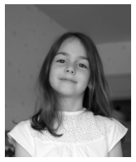

```python
import cv2
import matplotlib.pyplot as plt

img = cv2.imread('girl2.jpg')

# 그레이스케일로 변환
img = cv2.cvtColor(img, cv2.COLOR_BGR2GRAY)


plt.imshow(img, cmap='gray')
plt.axis('off')
plt.show()
```

- 사용 가능한 모든 색상의 값을 출력

```python
import cv2

[i for i in dir(cv2) if i.startswith('COLOR_')]
```

[output not shown]

[output cut: 219 more lines]

```
 'COLOR_YUV420SP2BGRA',
 'COLOR_YUV420SP2GRAY',
 'COLOR_YUV420SP2RGB',
 'COLOR_YUV420SP2RGBA',
 'COLOR_YUV420p2BGR',
 'COLOR_YUV420p2BGRA',
 'COLOR_YUV420p2GRAY',
 'COLOR_YUV420p2RGB',
 'COLOR_YUV420p2RGBA',
 'COLOR_YUV420sp2BGR',
 'COLOR_YUV420sp2BGRA',
 'COLOR_YUV420sp2GRAY',
 'COLOR_YUV420sp2RGB',
 'COLOR_YUV420sp2RGBA',
 'COLOR_mRGBA2RGBA']
```

- 그레이스케일2

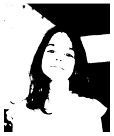

```python
import cv2
import matplotlib.pyplot as plt

img = cv2.imread('girl2.jpg')

# 그레이스케일로 변환
img = cv2.cvtColor(img, cv2.COLOR_BGR2GRAY)

# 역치 지정
th = 90
img[img > th] = 255
img[img < th] = 0

plt.imshow(img, cmap='gray')
plt.axis('off')
plt.show()
```

- 엣지 검출

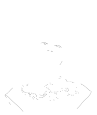

```python
import cv2
import matplotlib.pyplot as plt

img = cv2.imread('girl2.jpg')

# 그레이스케일로 변환
img = cv2.cvtColor(img, cv2.COLOR_BGR2GRAY)

# 엣지 지정
img = cv2.Canny(img, 100, 200, 255)
img = 255 - img

plt.imshow(img, cmap='gray')
plt.axis('off')
plt.show()
```

[figure not shown]

```python
import cv2
import matplotlib.pyplot as plt

img = cv2.imread('1.png')

# 그레이스케일로 변환
img = cv2.cvtColor(img, cv2.COLOR_BGR2GRAY)


plt.imshow(img, cmap='gray')
plt.axis('off')
plt.show()
```